# How Top-Heavy Is Global Wealth? A Pareto Model for the Forbes Billionaires of 2021

AUA CS 108 Statistics, Fall 2026 — Project 2: Point Estimation and Confidence Intervals in Practice

Group members: Mari Minasyan, Aida Kirakosyan, Liana Petrosyan

November 2026

# 1. Problem Description

**Practical question.** People often say that “a tiny minority owns most of the wealth”. Can we put a number on how top-heavy the wealth of the world’s richest people is? Within the group of billionaires itself, how strongly is wealth concentrated at the very top: how much do the richest 1%, 5% or 10% of billionaires own out of the total billionaire wealth?

**Parameter of interest.** Wealth above a high level is classically modelled by the **Pareto distribution** (Pareto, 1896). Its *tail index* $\alpha>0$ measures how heavy the tail is: the smaller $\alpha$, the more concentrated the wealth. Our main parameter is $\alpha$. We also estimate functions of $\alpha$ that answer the practical question:

- the **tail probability** $P(X>x)=x^{-\alpha}$ (for a billionaire’s wealth in billions of USD, with threshold $4B),
- the **top share** $S(p)$ = share of the total wealth owned by the richest fraction $p$ of billionaires,
- the **Gini coefficient** of billionaire wealth, $G=1/(2\alpha-1)$,
- the value of $\alpha$ for which the “80/20 rule” holds.

**Data-generating mechanism and assumptions.**

- One observation is the net worth (in billions of USD) of one person on the Forbes 2021 list.Although Forbes includes everyone with a net worth of at least $1B, we restrict our sample to individuals with at least $4B, so the data are left-truncated at a chosen threshold $x_m = 4$ (billion USD) where the Pareto tail behavior holds. This is the exact situation where the Pareto model is natural, because a Pareto variable conditioned to exceed a higher threshold is again Pareto with the same $\alpha$.
- We treat the observations as i.i.d. from a Pareto distribution above $x_m$. This is an approximation: the list is a (near) census of billionaires rather than a random sample, and some fortunes are linked (families, shared companies). We discuss consequences in the conclusions.
- Net worths are published rounded to $0.1B, so there are many ties. We account for this in the goodness-of-fit test (rounded bootstrap samples).

# 2. The Model

## Pareto (Type I) distribution

$X\sim \text{Pareto}(\alpha, x_m)$ with scale (threshold) $x_m>0$ and shape (tail index) $\alpha>0$:

$$f(x)=\frac{\alpha\,x_m^{\alpha}}{x^{\alpha+1}},\quad x\ge x_m,\qquad
F(x)=1-\Big(\frac{x_m}{x}\Big)^{\alpha},\qquad
Q(u)=x_m(1-u)^{-1/\alpha}.$$

$$E(X)=\frac{\alpha x_m}{\alpha-1}\ (\alpha>1),\qquad
\operatorname{Var(X)}=\frac{\alpha x_m^2}{(\alpha-1)^2(\alpha-2)}\
(\alpha>2).$$

The mean is infinite for $\alpha\le 1$ and the variance is infinite for $\alpha\le 2$. This matters for the method of moments (Section 5).

**Key fact used throughout.** If $X\sim\text{Pareto}(\alpha,x_m)$ then $\ln(X/x_m)\sim\text{Exp}(\alpha)$. Hence, for an i.i.d. sample,
$$T=\sum_{i=1}^n
\ln\frac{X_i}{x_m}\sim\text{Gamma}(n,\alpha),\qquad\text{equivalently}\qquad
2\alpha T\sim\chi^2_{2n}.$$

## Functions of the parameter (derivations)

*Top share.* Let $q=x_m p^{-1/\alpha}$ be the point above which a fraction $p$ of the population lies. For $\alpha>1$,
$$S(p)=\frac{\int_q^\infty x f(x)\,dx}{E X}
=\frac{\alpha x_m^\alpha q^{1-\alpha}/(\alpha-1)}{\alpha x_m/(\alpha-1)}
=\Big(\frac{q}{x_m}\Big)^{1-\alpha}=p^{\,1-1/\alpha}.$$
For $\alpha\le1$ the mean is infinite and $S(p)=1$ in the limit. $S(p)$ is a decreasing function of $\alpha$.

*Gini coefficient.* For $\alpha>1$: $G=\dfrac{1}{2\alpha-1}$, decreasing in $\alpha$.

*80/20 rule.* Solving $0.2^{\,1-1/\alpha}=0.8$ gives $\alpha_{80/20}=\dfrac{1}{1-\ln0.8/\ln0.2}\approx 1.161$.

# 3. Dataset

**Source.** *Forbes Billionaires of 2021* (Kaggle, user `roysouravcu`): https://www.kaggle.com/datasets/roysouravcu/forbes-billionaires-of-2021. The original data are the Forbes World’s Billionaires List 2021 (https://www.forbes.com/billionaires/).

**One observation** = one billionaire on the 2021 list. **Population/context:** the world’s billionaires as of the 2021 ranking. **Variable used:** `NetWorth`, the net worth in **billions of US dollars**. Additional variables (country, industry) are used only in a small supplementary comparison.

> Download the CSV from Kaggle and place it in the same folder as this `.Rmd` (default name `Billionaire.csv`). The code below also searches the working directory for any file matching `forbes*.csv`.

## Data import and preparation

```r
if (!file.exists(DATA_FILE)) {
  cand <- list.files(".", pattern = "forbes.*\\.csv$", ignore.case = TRUE, recursive = TRUE)
  if (length(cand) == 0) stop("Dataset not found. Place the Kaggle CSV next to this .Rmd file.")
  DATA_FILE <- cand[1]
}
raw <- read.csv(DATA_FILE, stringsAsFactors = FALSE, check.names = FALSE)
cat("File used:", DATA_FILE, "\n")
```

```
## File used: Billionaire.csv
```

```r
cat("Rows:", nrow(raw), " Columns:", ncol(raw), "\n")
```

```
## Rows: 2755  Columns: 7
```

```r
str(raw)
```

```
## 'data.frame':    2755 obs. of  7 variables:
##  $ Name    : chr  "Jeff Bezos" "Elon Musk" "Bernard Arnault & family" "Bill Gates" ...
##  $ NetWorth: chr  "$177 B" "$151 B" "$150 B" "$124 B" ...
##  $ Country : chr  "United States" "United States" "France" "United States" ...
##  $ Source  : chr  "Amazon" "Tesla, SpaceX" "LVMH" "Microsoft" ...
##  $ Rank    : int  1 2 3 4 5 6 7 8 9 10 ...
##  $ Age     : chr  "57" "49" "72" "65" ...
##  $ Industry: chr  "Technology" "Automotive" "Fashion & Retail" "Technology" ...
```

```r
head(raw)
```

|  | Name | NetWorth | Country | Source | Rank | Age | Industry |
| --- | --- | --- | --- | --- | --- | --- | --- |
| 1 | Jeff Bezos | $177 B | United States | Amazon | 1 | 57 | Technology |
| 2 | Elon Musk | $151 B | United States | Tesla, SpaceX | 2 | 49 | Automotive |
| 3 | Bernard Arnault & family | $150 B | France | LVMH | 3 | 72 | Fashion & Retail |
| 4 | Bill Gates | $124 B | United States | Microsoft | 4 | 65 | Technology |
| 5 | Mark Zuckerberg | $97 B | United States | Facebook | 5 | 36 | Technology |
| 6 | Warren Buffett | $96 B | United States | Berkshire Hathaway | 6 | 90 | Finance & Investments |

```r
# --- 1. locate the net-worth column and convert strings such as "$177 B" to numbers
nw_col <- grep("net ?worth|networth|wealth", names(raw), ignore.case = TRUE, value = TRUE)[1]
if (is.na(nw_col)) stop("No net-worth column found; check names(raw).")
nw_raw <- raw[[nw_col]]
nw <- if (is.numeric(nw_raw)) nw_raw else as.numeric(gsub("[^0-9.]", "", nw_raw))
cat("Net-worth column used:", nw_col, "\n")
```

```
## Net-worth column used: NetWorth
```

```r
# --- 2. missing values
n_na <- sum(is.na(nw))
cat("Missing / unparseable net-worth values:", n_na, "\n")
```

```
## Missing / unparseable net-worth values: 0
```

```r
# --- 3. units check (we need billions of USD)
if (max(nw, na.rm = TRUE) > 1000) {
  message("Values look like millions of USD; dividing by 1000 to express them in billions.")
  nw <- nw / 1000
}

# --- 4. duplicates (same person listed twice?)
name_col <- grep("^name$|person", names(raw), ignore.case = TRUE, value = TRUE)[1]
if (!is.na(name_col)) cat("Duplicated names:", sum(duplicated(raw[[name_col]])), "\n")
```

```
## Duplicated names: 3
```

```r
# --- 5. observations below the Forbes cut-off of $4B
XM <- 4                                  # known truncation threshold ($4B)
n_below <- sum(nw < XM, na.rm = TRUE)
cat("Observations below the $4B threshold:", n_below, "\n")
```

```
## Observations below the $4B threshold: 2004
```

```r
x <- nw[!is.na(nw) & nw >= XM]
n <- length(x)
cat("Final sample size n =", n, "\n")
```

```
## Final sample size n = 751
```

```r
summary(x)
```

```
##    Min. 1st Qu.  Median    Mean 3rd Qu.    Max.
##    4.00    5.00    7.00   12.03   11.70  177.00
```

```r
tab_top <- data.frame(Rank = 1:5, NetWorth_B = sort(x, decreasing = TRUE)[1:5])
knitr::kable(tab_top, caption = "Five largest fortunes in the sample (USD billions)")
```

Five largest fortunes in the sample (USD billions)

| Rank | NetWorth_B |
| --- | --- |
| 1 | 177 |
| 2 | 151 |
| 3 | 150 |
| 4 | 124 |
| 5 | 97 |

```r
cat("Number of distinct values:", length(unique(x)), " of ", n, "\n")
```

```
## Number of distinct values: 215  of  751
```

```r
cat("Share of observations equal to the minimum:", round(mean(x == min(x)), 3), "\n")
```

```
## Share of observations equal to the minimum: 0.033
```

**Independence.** The observations are not a random sample: Forbes lists (nearly) *all* billionaires, so there is no sampling randomness in the usual sense; the “randomness” is the stochastic mechanism that generated fortunes. Some fortunes are related (family members, the same company). We treat the values as i.i.d. draws from the Pareto model and discuss this limitation in the conclusions.

# 4. Is the Pareto Model Reasonable for These Data?

## Fitted model used in the diagrams

With the threshold $x_m=4$ known, the MLE is $\hat\alpha=n/T$ (derived in Section 5). We compute it here only to draw the diagnostic plots.

```r
# ---- Pareto functions ---------------------------------------------------
dpareto <- function(x, alpha, xm = 4) ifelse(x < xm, 0, alpha * xm^alpha / x^(alpha + 1))
ppareto <- function(x, alpha, xm = 4) ifelse(x < xm, 0, 1 - (xm / x)^alpha)
qpareto <- function(p, alpha, xm = 4) xm * (1 - p)^(-1 / alpha)
rpareto <- function(n, alpha, xm = 4) xm * runif(n)^(-1 / alpha)

# ---- estimators (xm known) ----------------------------------------------
T_stat    <- function(x, xm = 4) sum(log(x / xm))
alpha_mle <- function(x, xm = 4) length(x) / T_stat(x, xm)
alpha_unb <- function(x, xm = 4) (length(x) - 1) / T_stat(x, xm)   # UMVUE
alpha_mse <- function(x, xm = 4) (length(x) - 2) / T_stat(x, xm)   # minimum-MSE multiple of 1/T
alpha_mom <- function(x, xm = 4) { m <- mean(x); m / (m - xm) }   # method of moments

# ---- functions of alpha -------------------------------------------------
top_share <- function(alpha, p) ifelse(alpha > 1, p^(1 - 1 / alpha), 1)
gini_par  <- function(alpha) ifelse(alpha > 1, 1 / (2 * alpha - 1), 1)
alpha_8020 <- 1 / (1 - log(0.8) / log(0.2))

alpha_hat <- alpha_mle(x, XM)
Tn <- T_stat(x, XM)
cat("alpha_hat (MLE) =", round(alpha_hat, 4), "\n")
```

```
## alpha_hat (MLE) = 1.3243
```

## Graphical methods

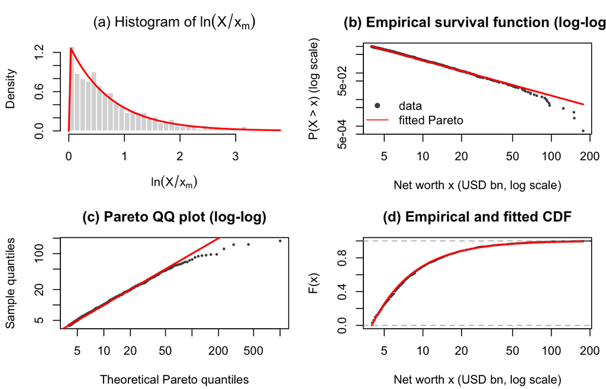

```r
par(mfrow = c(2, 2), mar = c(4.2, 4.2, 3, 1))

# (a) histogram of log(X/xm) with fitted exponential density  [Pareto <=> log is exponential]
lx <- log(x / XM)
hist(lx, breaks = 40, freq = FALSE, col = "grey85", border = "white",
     main = expression("(a) Histogram of " * ln(X / x[m])), xlab = expression(ln(X / x[m])))
curve(dexp(x, rate = alpha_hat), add = TRUE, col = "red", lwd = 2)

# (b) log-log survival plot: Pareto => straight line with slope -alpha
xs <- sort(x); surv <- 1 - (seq_len(n) - 0.5) / n
plot(xs, surv, log = "xy", pch = 16, cex = 0.5, col = "grey30",
     xlab = "Net worth x (USD bn, log scale)", ylab = "P(X > x) (log scale)",
     main = "(b) Empirical survival function (log-log)")
curve(XM^alpha_hat * x^(-alpha_hat), add = TRUE, col = "red", lwd = 2, from = XM, to = max(x))
legend("bottomleft", legend = c("data", "fitted Pareto"), col = c("grey30", "red"),
       pch = c(16, NA), lty = c(NA, 1), bty = "n")

# (c) QQ plot against fitted Pareto (log-log)
pp <- (seq_len(n) - 0.5) / n
tq <- qpareto(pp, alpha_hat, XM)
plot(tq, xs, log = "xy", pch = 16, cex = 0.5, col = "grey30",
     xlab = "Theoretical Pareto quantiles", ylab = "Sample quantiles",
     main = "(c) Pareto QQ plot (log-log)")
abline(0, 1, col = "red", lwd = 2)

# (d) ECDF with fitted CDF (x on log scale)
plot(ecdf(x), log = "x", verticals = FALSE, do.points = FALSE, col = "grey30", lwd = 2,
     xlim = c(XM, max(x)), main = "(d) Empirical and fitted CDF", xlab = "Net worth x (USD bn, log scale)",
     ylab = "F(x)")
curve(ppareto(x, alpha_hat, XM), add = TRUE, col = "red", lwd = 2, from = XM, to = max(x))
```

**How to read the plots.** If $X$ is Pareto, then (a) $\ln(X/x_m)$ is exponential, (b) the log-log survival plot is a straight line with slope $-\alpha$, and (c) the Pareto QQ plot lies on the diagonal. Systematic bending of the points shows where the model fails (typically the bulk near the very top where only a handful of points are observed).

## Formal goodness-of-fit test (parametric bootstrap Kolmogorov–Smirnov)

```r
ks_stat <- function(x, alpha, xm = 4) {
  x <- sort(x); n <- length(x); F <- ppareto(x, alpha, xm)
  max(pmax(abs((1:n) / n - F), abs(F - (0:(n - 1)) / n)))
}
D_obs <- ks_stat(x, alpha_hat, 4)
set.seed(SEED)
D_boot <- replicate(B_BOOT, {
  xb <- round(rpareto(n, alpha_hat, 4), 1)
  xb <- pmax(xb, 4)
  ks_stat(xb, alpha_mle(xb, 4), 4)
})
p_boot <- (1 + sum(D_boot >= D_obs)) / (B_BOOT + 1)
cat("Observed D =", round(D_obs, 4), "  bootstrap p-value =", round(p_boot, 4), "\n")
```

```
## Observed D = 0.0426   bootstrap p-value = 0.0879
```

# 5. Estimators and Their Properties

## Construction

**Maximum likelihood.** The likelihood is $L(\alpha)=\alpha^n x_m^{n\alpha}\prod X_i^{-(\alpha+1)}$, so
$$\ell(\alpha)=n\ln\alpha+n\alpha\ln x_m-(\alpha+1)\sum\ln X_i,\qquad
\ell'(\alpha)=\frac n\alpha-T=0\ \Rightarrow\
\boxed{\hat\alpha_{MLE}=\frac nT}.$$
Since $\ell''(\alpha)=-n/\alpha^2<0$, this is a global maximum.

**Method of moments.** From $E(X)=\alpha x_m/(\alpha-1)$ we get $\alpha=\bar X/(\bar X-x_m)$, hence
$$\boxed{\bar\alpha_{MoM}=\frac{\bar X}{\bar X-x_m}}.$$
This requires $\alpha>1$ for the first moment to exist.

**Bias-corrected and minimum-MSE versions.** Since $T\sim\text{Gamma}(n,\alpha)$, we have $E[1/T]=\dfrac{\alpha}{n-1}$ and $E[1/T^2]=\dfrac{\alpha^2}{(n-1)(n-2)}$ (for $n>2$). This suggests the family $c/T$.

```r
est <- c(MLE = alpha_mle(x, XM), UMVUE = alpha_unb(x, XM),
         MinMSE = alpha_mse(x, XM), MoM = alpha_mom(x, XM))
print(round(est, 4))
```

```
##    MLE  UMVUE MinMSE    MoM
## 1.3243 1.3225 1.3207 1.4979
```

## Properties of the estimators (analytic)

**Bias of the MLE.** $E\hat\alpha_{ML}=nE[1/T]=\dfrac{n}{n-1}\alpha$. The MLE **overestimates** $\alpha$, with bias $\dfrac{\alpha}{n-1}$. It is asymptotically unbiased, hence **consistent** (also, $T/n\to 1/\alpha$ a.s. by the law of large numbers).

**Unbiased version.** $\hat\alpha_{U}=\dfrac{n-1}{n}\hat\alpha_{ML}=\dfrac{n-1}{T}$ is unbiased.

**Variances.** $\operatorname{Var}(1/T)=\dfrac{\alpha^2}{(n-1)(n-2)}-\dfrac{\alpha^2}{(n-1)^2}=\dfrac{\alpha^2}{(n-1)^2(n-2)}$, so
$$\operatorname{Var}(\hat\alpha_{ML})=\frac{n^2\alpha^2}{(n-1)^2(n-2)},\qquad
\operatorname{Var}(\hat\alpha_{U})=\frac{\alpha^2}{n-2}.$$

**MSE and bias-variance decomposition.** For $\hat\alpha_c=c/T$:
$$\operatorname{MSE}(\hat\alpha_c)=\alpha^2\Big[\frac{c^2}{(n-1)(n-2)}-\frac{2c}{n-1}+1\Big].$$
* MLE ($c=n$): $\ \text{MSE}=\alpha^2\dfrac{(n+2)}{(n-1)(n-2)}$ = $\dfrac{\alpha^2 n^2}{(n-1)^2(n-2)}+\dfrac{\alpha^2}{(n-1)^2}$ (variance + bias$^2$). * UMVUE ($c=n-1$): $\ \text{MSE}=\dfrac{\alpha^2}{n-2}$. * Minimising over $c$: derivative $=0$ gives $c=n-2$, and $\text{MSE}_{\min}=\dfrac{\alpha^2}{n-1}$. So the **minimum-MSE** estimator in this family is $\hat\alpha_{MSE}=(n-2)/T$, which is *biased downwards* but has the smallest MSE for every $n$ and $\alpha$.

**Ranking:** $\text{MSE}(\hat\alpha_{MSE})<\text{MSE}(\hat\alpha_U)<\text{MSE}(\hat\alpha_{ML})$ for all $n>2$; the differences are of order $1/n^2$ and negligible for large $n$.

**Sufficiency, completeness, MVUE.** The density is a one-parameter exponential family in $T$ with natural parameter $-\alpha$ (open range), so $T$ is **complete and sufficient**. By the Lehmann–Scheffé theorem $\hat\alpha_U=(n-1)/T$, an unbiased function of $T$, is the **unique MVUE**.

**Fisher information and the Cramér–Rao bound.** $\ln f=\ln\alpha+\alpha\ln x_m-(\alpha+1)\ln x$, so $\partial^2/\partial\alpha^2\ln f=-1/\alpha^2$ and $I(\alpha)=1/\alpha^2$ per observation. The bound for unbiased estimators is $\alpha^2/n$. The MVUE has variance $\alpha^2/(n-2)>\alpha^2/n$, i.e. **it does not attain the bound** for finite $n$ (the bound is attained only for estimators of the mean parameter $1/\alpha$, not for $\alpha$), but the ratio $n/(n-2)\to1$: the estimator is asymptotically efficient.

**Asymptotics.** $\sqrt n(\hat\alpha_{ML}-\alpha)\xrightarrow{d}N(0,\alpha^2)$, so the estimated standard error is $\widehat{SE}(\hat\alpha_{ML})=\hat\alpha/\sqrt n$. For the UMVUE one can use the exact $\widehat{SE}=\hat\alpha_U/\sqrt{n-2}$.

**Method of moments.** By the delta method with $g(\mu)=\mu/(\mu-1)$, $g'(\mu)=-1/(\mu-1)^2$, and if $\alpha>2$,
$$\operatorname{AVar}(\tilde\alpha_{MM})=\frac{g'(\mu)^2\sigma^2}{n}=\frac{\alpha(\alpha-1)^2}{n(\alpha-2)}.$$
This exceeds the Cramér–Rao bound $\alpha^2/n$ (ratio $=(\alpha-1)^2/(\alpha(\alpha-2))>1$), so MoM is **less efficient**. If $\alpha\le2$ the variance of $X$ is infinite, the CLT does not apply, the MoM estimator converges slowly and is not asymptotically normal; and if $\alpha\le 1$ the population mean does not exist at all and MoM is inconsistent. Since wealth data typically have $\alpha$ close to 1–2, MoM is expected to be poor here, which we verify by simulation.

## Properties by simulation

We fix the true parameter $\alpha_0$ (the rounded estimate from the real data), simulate $B$ samples of each size $n$ and compute the empirical bias, variance and MSE of each estimator. The theoretical values for the MLE are shown for comparison.

```r
alpha0 <- round(alpha_hat, 2)
cat("True value used in simulations: alpha0 =", alpha0, "\n")
```

```
## True value used in simulations: alpha0 = 1.32
```

```r
# T and sample mean for B replications of size n (processed in chunks to save memory)
sim_stats <- function(B, n, alpha, xm = 1) {
  chunk <- max(1, floor(2e6 / n)); res <- matrix(NA_real_, B, 2); done <- 0
  while (done < B) {
    b <- min(chunk, B - done)
    X <- xm * matrix(runif(b * n), b, n)^(-1 / alpha)
    res[done + seq_len(b), ] <- cbind(rowSums(log(X / xm)), rowMeans(X))
    done <- done + b
  }
  colnames(res) <- c("T", "xbar"); res
}

ns_prop <- c(10, 20, 50, 100, 200, 500, 1000)
set.seed(SEED)
prop_tab <- do.call(rbind, lapply(ns_prop, function(nn) {
  S <- sim_stats(B_SIM, nn, alpha0, XM)
  E <- cbind(MLE = nn / S[, "T"], UMVUE = (nn - 1) / S[, "T"], MinMSE = (nn - 2) / S[, "T"],
             MoM = S[, "xbar"] / (S[, "xbar"] - XM))
  data.frame(n = nn, estimator = colnames(E),
             bias = colMeans(E) - alpha0, variance = apply(E, 2, var),
             MSE = colMeans((E - alpha0)^2), row.names = NULL)
}))
prop_tab$RMSE <- sqrt(prop_tab$MSE)
knitr::kable(subset(prop_tab, n %in% c(10, 50, 200, 1000)), digits = 4,
             caption = "Simulated bias, variance and MSE (selected n)")
```

Simulated bias, variance and MSE (selected n)

|  | n | estimator | bias | variance | MSE | RMSE |
| --- | --- | --- | --- | --- | --- | --- |
| 1 | 10 | MLE | 0.1551 | 0.2772 | 0.3012 | 0.5489 |
| 2 | 10 | UMVUE | 0.0076 | 0.2246 | 0.2246 | 0.4739 |
| 3 | 10 | MinMSE | -0.1399 | 0.1774 | 0.1970 | 0.4438 |
| 4 | 10 | MoM | 0.3925 | 0.2447 | 0.3987 | 0.6314 |
| 9 | 50 | MLE | 0.0244 | 0.0365 | 0.0370 | 0.1925 |
| 10 | 50 | UMVUE | -0.0025 | 0.0350 | 0.0350 | 0.1871 |
| 11 | 50 | MinMSE | -0.0294 | 0.0336 | 0.0345 | 0.1856 |
| 12 | 50 | MoM | 0.1565 | 0.0412 | 0.0656 | 0.2562 |
| 17 | 200 | MLE | 0.0078 | 0.0089 | 0.0090 | 0.0948 |
| 18 | 200 | UMVUE | 0.0012 | 0.0088 | 0.0088 | 0.0940 |
| 19 | 200 | MinMSE | -0.0055 | 0.0087 | 0.0088 | 0.0937 |
| 20 | 200 | MoM | 0.0868 | 0.0158 | 0.0233 | 0.1527 |
| 25 | 1000 | MLE | 0.0006 | 0.0018 | 0.0018 | 0.0420 |
| 26 | 1000 | UMVUE | -0.0007 | 0.0018 | 0.0018 | 0.0420 |
| 27 | 1000 | MinMSE | -0.0021 | 0.0018 | 0.0018 | 0.0420 |
| 28 | 1000 | MoM | 0.0434 | 0.0065 | 0.0084 | 0.0916 |

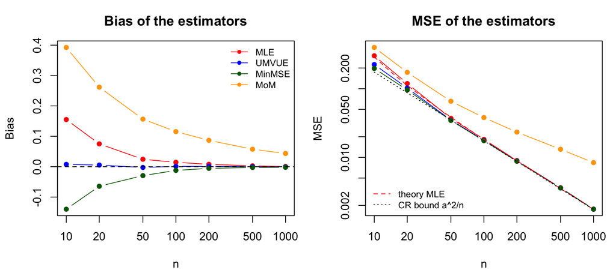

```r
par(mfrow = c(1, 2), mar = c(4.2, 4.2, 3, 1))
cols <- c(MLE = "red", UMVUE = "blue", MinMSE = "darkgreen", MoM = "orange")
plot(NA, xlim = range(ns_prop), ylim = range(prop_tab$bias), log = "x",
     xlab = "n", ylab = "Bias", main = "Bias of the estimators")
for (e in names(cols)) with(subset(prop_tab, estimator == e), lines(n, bias, type = "b", col = cols[e], pch = 16))
abline(h = 0, lty = 2)
legend("topright", legend = names(cols), col = cols, pch = 16, lty = 1, bty = "n", cex = 0.8)

plot(NA, xlim = range(ns_prop), ylim = range(prop_tab$MSE), log = "xy",
     xlab = "n", ylab = "MSE", main = "MSE of the estimators")
for (e in names(cols)) with(subset(prop_tab, estimator == e), lines(n, MSE, type = "b", col = cols[e], pch = 16))
nn <- seq(ns_prop[1], ns_prop[length(ns_prop)])
lines(nn, alpha0^2 * (nn + 2) / ((nn - 1) * (nn - 2)), lty = 2, col = "red")      # theory, MLE
lines(nn, alpha0^2 / nn, lty = 3)                                                # Cramer-Rao bound
legend("bottomleft", legend = c("theory MLE", "CR bound a^2/n"), lty = c(2, 3),
       col = c("red", "black"), bty = "n", cex = 0.8)
```

```r
par(mfrow = c(1, 1))
```

## Extension: unknown threshold $x_m$

Suppose we did not know the cut-off. Then $\hat x_m=\min X_i$ and $\hat\alpha=n/\sum\ln(X_i/\hat x_m)$. It is known that $T'=\sum\ln(X_i/\hat x_m)\sim\text{Gamma}(n-1,\alpha)$ and is independent of $\hat x_m$, so $(n-2)/T'$ is unbiased. This model is *non-regular* (the support depends on $x_m$; the Cramér–Rao bound does not apply to $x_m$, and $\hat x_m$ converges at rate $1/n$).

```r
xm_hat <- min(x); Tp <- sum(log(x / xm_hat))
cat("min(x) =", xm_hat, "\n",
    "alpha_hat (xm estimated) =", round(n / Tp, 4), "\n",
    "unbiased version =", round((n - 2) / Tp, 4), "\n")
```

```
## min(x) = 4
##  alpha_hat (xm estimated) = 1.3243
##  unbiased version = 1.3207
```

## Estimates and conclusions about the problem

```r
a_mle <- alpha_mle(x, XM); a_u <- alpha_unb(x, XM)
res <- data.frame(
  Estimator = c("MLE", "UMVUE", "Min-MSE", "Method of moments"),
  Estimate  = c(a_mle, a_u, alpha_mse(x, XM), alpha_mom(x, XM)),
  SE        = c(a_mle / sqrt(n), a_u / sqrt(n - 2), alpha_mse(x, XM) / sqrt(n - 1), NA))
knitr::kable(res, digits = 4, caption = "Estimates of the tail index alpha with estimated standard errors")
```

Estimates of the tail index alpha with estimated standard errors

| Estimator | Estimate | SE |
| --- | --- | --- |
| MLE | 1.3243 | 0.0483 |
| UMVUE | 1.3225 | 0.0483 |
| Min-MSE | 1.3207 | 0.0482 |
| Method of moments | 1.4979 | NA |

*Standard errors.* MLE: $\hat\alpha/\sqrt n$; UMVUE: $\hat\alpha_U/\sqrt{n-2}$; min-MSE: $\hat\alpha_{MSE}/\sqrt{n-1}$ (root of its MSE, i.e. accounting for bias). For MoM the standard error requires $\alpha>2$ and is unreliable here, so it is not reported.

```r
ps <- c(0.01, 0.05, 0.10, 0.20, 0.50)
emp_share <- sapply(ps, function(p) { k <- ceiling(p * n); sum(sort(x, decreasing = TRUE)[1:k]) / sum(x) })
shares <- data.frame(Top_fraction = ps, Model_share = top_share(a_u, ps), Empirical_share = emp_share)
knitr::kable(shares, digits = 3,
  caption = "Share of total billionaire wealth owned by the richest fraction p of billionaires (model with UMVUE alpha vs. data)")
```

Share of total billionaire wealth owned by the richest fraction p of billionaires (model with UMVUE alpha vs. data)

| Top_fraction | Model_share | Empirical_share |
| --- | --- | --- |
| 0.01 | 0.325 | 0.108 |
| 0.05 | 0.325 | 0.290 |
| 0.10 | 0.325 | 0.407 |
| 0.20 | 0.325 | 0.550 |
| 0.50 | 0.325 | 0.785 |

```r
cat("Gini (model):", round(gini_par(a_u), 3), "\n")
```

```
## Gini (model): 0.608
```

```r
cat("Gini (empirical):", round({ s <- sort(x); i <- 1:n; 2 * sum(i * s) / (n * sum(s)) - (n + 1) / n }, 3), "\n")
```

```
## Gini (empirical): 0.461
```

```r
cat("alpha for the 80/20 rule:", round(alpha_8020, 3), "\n")
```

```
## alpha for the 80/20 rule: 1.161
```

**Interpretation.** A **smaller** $\alpha$ means a heavier tail and more concentration. The table compares the model-implied top shares (computed from $\hat\alpha$) with the shares actually observed in the sample; differences measure how far the Pareto approximation is from the data. If $\hat\alpha\le1$, the Pareto model would imply an infinite mean, which is not credible in a finite population; this would show that the fitted Pareto is only an approximation for the observed range of wealth.

# 6. Confidence Intervals

## Construction

Let $\hat\alpha=n/T$ be the MLE and $z=z_{1-(1-\text{level})/2}$ the normal quantile.

1. **Exact (pivot).** Since $2\alpha T\sim\chi^2_{2n}$ is a pivot,
   $$P\Big(\chi^2_{2n,\gamma/2}\le 2\alpha
   T\le\chi^2_{2n,1-\gamma/2}\Big)=1-\gamma
   \ \Rightarrow\
   \Big[\frac{\chi^2_{2n,\gamma/2}}{2T},\
   \frac{\chi^2_{2n,1-\gamma/2}}{2T}\Big].$$
2. **Asymptotic Wald.** $\hat\alpha\pm z\,\hat\alpha/\sqrt n$, from $\sqrt n(\hat\alpha-\alpha)\to N(0,1/I(\alpha))=N(0,\alpha^2)$.
3. **Wald on the log scale (delta method).** $\operatorname{Var}(\ln\hat\alpha)\approx\frac{1}{\alpha^2}\cdot\frac{\alpha^2}{n}=\frac1n$, so $\ln\hat\alpha\pm z/\sqrt n$, i.e. $\big[\hat\alpha e^{-z/\sqrt n},\ \hat\alpha e^{z/\sqrt n}\big]$. It is always positive and respects the skewness of $\hat\alpha$.
4. **Likelihood ratio (profile likelihood).** $\{\alpha:\ 2[\ell(\hat\alpha)-\ell(\alpha)]\le\chi^2_{1,\text{level}}\}$. Using $T=n/\hat\alpha$ and $r=\alpha/\hat\alpha$, $2[\ell(\hat\alpha)-\ell(\alpha)]=2n\,(r-1-\ln r)$, so the interval is $\hat\alpha\cdot[r_L,r_U]$ where $r_L<1<r_U$ are the two roots of $2n(r-1-\ln r)=\chi^2_{1,\text{level}}$. These roots depend only on $n$ and are found numerically.

```r
ci_exact <- function(Tn, n, level = LEVEL) {
  g <- 1 - level
  cbind(lower = qchisq(g / 2, 2 * n) / (2 * Tn), upper = qchisq(1 - g / 2, 2 * n) / (2 * Tn))
}
ci_wald <- function(Tn, n, level = LEVEL) {
  a <- n / Tn; z <- qnorm(1 - (1 - level) / 2)
  cbind(lower = a - z * a / sqrt(n), upper = a + z * a / sqrt(n))
}
ci_logwald <- function(Tn, n, level = LEVEL) {
  a <- n / Tn; z <- qnorm(1 - (1 - level) / 2)
  cbind(lower = a * exp(-z / sqrt(n)), upper = a * exp(z / sqrt(n)))
}
lr_roots <- function(n, level = LEVEL) {
  crit <- qchisq(level, 1)
  f <- function(r) 2 * n * (r - 1 - log(r)) - crit
  c(rL = uniroot(f, c(1e-10, 1), tol = 1e-12)$root,
    rU = uniroot(f, c(1, 1e4), tol = 1e-12)$root)
}
ci_lr <- function(Tn, n, level = LEVEL) {
  rr <- lr_roots(n, level); a <- n / Tn
  cbind(lower = a * rr["rL"], upper = a * rr["rU"])
}
```

```r
ci_tab <- rbind(Exact = ci_exact(Tn, n), Wald = ci_wald(Tn, n),
                `Wald (log scale)` = ci_logwald(Tn, n), `Likelihood ratio` = ci_lr(Tn, n))
ci_tab <- data.frame(Method = rownames(ci_tab), lower = ci_tab[, 1], upper = ci_tab[, 2],
                     length = ci_tab[, 2] - ci_tab[, 1], row.names = NULL)
knitr::kable(ci_tab, digits = 4,
             caption = paste0(100 * LEVEL, "% confidence intervals for alpha (real data, n = ", n, ")"))
```

95% confidence intervals for alpha (real data, n = 751)

| Method | lower | upper | length |
| --- | --- | --- | --- |
|  | 1.2312 | 1.4206 | 0.1894 |
|  | 1.2295 | 1.4190 | 0.1894 |
|  | 1.2328 | 1.4224 | 0.1896 |
| rL | 1.2318 | 1.4212 | 0.1894 |

**Interpretation.** The confidence level describes the *procedure*: if we could repeatedly draw samples from the model and build the interval in the same way, about 95% of those intervals would contain the true $\alpha$. It is **not** correct to say that the true $\alpha$ lies in this particular computed interval with probability 0.95.

## Confidence intervals for functions of $\alpha$

$S(p)=p^{1-1/\alpha}$, $G=1/(2\alpha-1)$ and $P(X>x)=x^{-\alpha}$ are **monotone** (decreasing) functions of $\alpha$ (for $\alpha>1$ in the first two cases). Hence applying the function to the endpoints of the exact interval for $\alpha$ gives an *exact* interval for each of them (the lower endpoint comes from the upper endpoint of $\alpha$ and vice versa), with the same confidence level and no additional approximation. In particular, their coverage equals that of the interval for $\alpha$.

```r
ci_a <- ci_exact(Tn, n)            # exact CI for alpha
al <- ci_a[1]; au <- ci_a[2]
fun_tab <- data.frame(
  Quantity = c("Top 1% share", "Top 10% share", "Gini coefficient", "P(X > $10B)", "P(X > $50B)"),
  Estimate = c(top_share(a_mle, 0.01), top_share(a_mle, 0.10), gini_par(a_mle), 10^(-a_mle), 50^(-a_mle)),
  Lower    = c(top_share(au, 0.01),    top_share(au, 0.10),    gini_par(au),    10^(-au),    50^(-au)),
  Upper    = c(top_share(al, 0.01),    top_share(al, 0.10),    gini_par(al),    10^(-al),    50^(-al)))
knitr::kable(fun_tab, digits = 4, caption = "Exact 95% CIs for functions of alpha (point estimates use the MLE)")
```

Exact 95% CIs for functions of alpha (point estimates use the MLE)

| Quantity | Estimate | Lower | Upper |
| --- | --- | --- | --- |
| Top 1% share | 0.3238 | 0.2558 | 0.4211 |
| Top 10% share | 0.5690 | 0.5057 | 0.6489 |
| Gini coefficient | 0.6066 | 0.5431 | 0.6838 |
| P(X > $10B) | 0.0474 | 0.0380 | 0.0587 |
| P(X > $50B) | 0.0056 | 0.0039 | 0.0081 |

Note that the 80/20 value $\alpha_{80/20}=$ 1.161 is outside the exact confidence interval for $\alpha$, i.e. the “80/20 rule” for the top 20% of billionaires is not compatible with the data at the chosen confidence level (the interval can be used as the acceptance region of a test of $H_0:\alpha=\alpha_{80/20}$).

## Supplementary comparison: countries (optional)

```r
cty_col <- grep("country", names(raw), ignore.case = TRUE, value = TRUE)[1]

if (!is.na(cty_col)) {
  d <- data.frame(x = nw, country = raw[[cty_col]])
  d <- d[!is.na(d$x) & d$x >= XM, ]

  # Pick the 3 countries with the largest number of billionaires
  top_c <- names(sort(table(d$country), decreasing = TRUE))[1:3]
  cty <- data.frame()

  for (cc in top_c) {
    xc <- d$x[d$country == cc]
    nc <- length(xc)
    Tc <- sum(log(xc / XM))
    ci <- ci_exact(Tc, nc)

    row_c <- data.frame(Country = cc, n = nc, alpha_hat = nc / Tc, CI_low = ci[1], CI_up = ci[2])
    cty <- rbind(cty, row_c)
  }

  knitr::kable(cty, digits = 3, caption = "Tail index by country (three largest groups); exact 95% CIs")
}
```

Tail index by country (three largest groups); exact 95% CIs

| Country | n | alpha_hat | CI_low | CI_up |
| --- | --- | --- | --- | --- |
| United States | 235 | 1.280 | 1.121 | 1.448 |
| China | 139 | 1.283 | 1.078 | 1.505 |
| Germany | 40 | 1.407 | 1.005 | 1.875 |

## Simulation study of the coverage probability

```r
alpha.true <- alpha0
conf.level <- LEVEL
a <- 1 - conf.level
z <- qnorm(1 - a / 2)

ns_cov <- sort(unique(c(10, 30, 100, 500, n)))
set.seed(SEED)
cov_res <- data.frame()

for (nn in ns_cov) {
  # Vectors to store lower and upper endpoints across B_SIM samples
  lo_exact <- numeric(B_SIM); up_exact <- numeric(B_SIM)
  lo_wald  <- numeric(B_SIM); up_wald  <- numeric(B_SIM)

  for (i in 1:B_SIM) {
    x_sim <- rpareto(nn, alpha = alpha.true, xm = XM)
    T_sim <- sum(log(x_sim / XM))
    alpha_hat <- nn / T_sim

    # 1. Exact Pivot CI: 2 * alpha * T ~ Chi-squared(2n)
    lo_exact[i] <- qchisq(a / 2, df = 2 * nn) / (2 * T_sim)
    up_exact[i] <- qchisq(1 - a / 2, df = 2 * nn) / (2 * T_sim)

    # 2. Asymptotic Normal (Wald) CI: alpha_hat +- ME
    ME <- z * alpha_hat / sqrt(nn)
    lo_wald[i] <- alpha_hat - ME
    up_wald[i] <- alpha_hat + ME
  }

  # Record Exact results
  cov_res <- rbind(cov_res, data.frame(
    n         = nn,
    Method    = "Exact",
    Coverage  = mean(lo_exact <= alpha.true & alpha.true <= up_exact),
    AvgLength = mean(up_exact - lo_exact),
    MissLow   = mean(up_exact < alpha.true),
    MissHigh  = mean(lo_exact > alpha.true)
  ))

  # Record Asymptotic Normal (Wald) results
  cov_res <- rbind(cov_res, data.frame(
    n         = nn,
    Method    = "Asymptotic Normal",
    Coverage  = mean(lo_wald <= alpha.true & alpha.true <= up_wald),
    AvgLength = mean(up_wald - lo_wald),
    MissLow   = mean(up_wald < alpha.true),
    MissHigh  = mean(lo_wald > alpha.true)
  ))
}

knitr::kable(cov_res, digits = 4, row.names = FALSE,
             caption = paste0("Empirical coverage (nominal ", LEVEL, ") and mean length; alpha0 = ", alpha.true))
```

Empirical coverage (nominal 0.95) and mean length; alpha0 = 1.32

| n | Method | Coverage | AvgLength | MissLow | MissHigh |
| --- | --- | --- | --- | --- | --- |
| 10 | Exact | 0.9490 | 1.8096 | 0.0234 | 0.0276 |
| 10 | Asymptotic Normal | 0.9544 | 1.8253 | 0.0406 | 0.0050 |
| 30 | Exact | 0.9522 | 0.9752 | 0.0236 | 0.0242 |
| 30 | Asymptotic Normal | 0.9526 | 0.9781 | 0.0338 | 0.0136 |
| 100 | Exact | 0.9488 | 0.5230 | 0.0234 | 0.0278 |
| 100 | Asymptotic Normal | 0.9502 | 0.5235 | 0.0274 | 0.0224 |
| 500 | Exact | 0.9468 | 0.2320 | 0.0250 | 0.0282 |
| 500 | Asymptotic Normal | 0.9456 | 0.2320 | 0.0284 | 0.0260 |
| 751 | Exact | 0.9522 | 0.1889 | 0.0258 | 0.0220 |
| 751 | Asymptotic Normal | 0.9524 | 0.1889 | 0.0274 | 0.0202 |

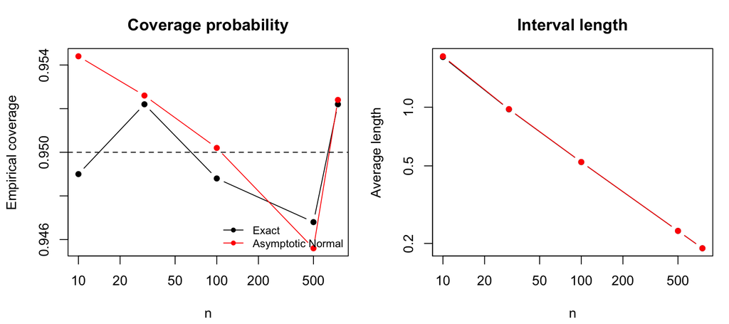

```r
par(mfrow = c(1, 2), mar = c(4.2, 4.2, 3, 1))
mcols <- c(Exact = "black", `Asymptotic Normal` = "red")

plot(NA, xlim = range(ns_cov), ylim = range(c(cov_res$Coverage, LEVEL)), log = "x",
     xlab = "n", ylab = "Empirical coverage", main = "Coverage probability")
for (m in names(mcols)) {
  sub_df <- cov_res[cov_res$Method == m, ]
  lines(sub_df$n, sub_df$Coverage, type = "b", pch = 16, col = mcols[m])
}
abline(h = LEVEL, lty = 2)
legend("bottomright", legend = names(mcols), col = mcols, pch = 16, lty = 1, bty = "n", cex = 0.8)

plot(NA, xlim = range(ns_cov), ylim = range(cov_res$AvgLength), log = "xy",
     xlab = "n", ylab = "Average length", main = "Interval length")
for (m in names(mcols)) {
  sub_df <- cov_res[cov_res$Method == m, ]
  lines(sub_df$n, sub_df$AvgLength, type = "b", pch = 16, col = mcols[m])
}
```

```r
par(mfrow = c(1, 1))
```

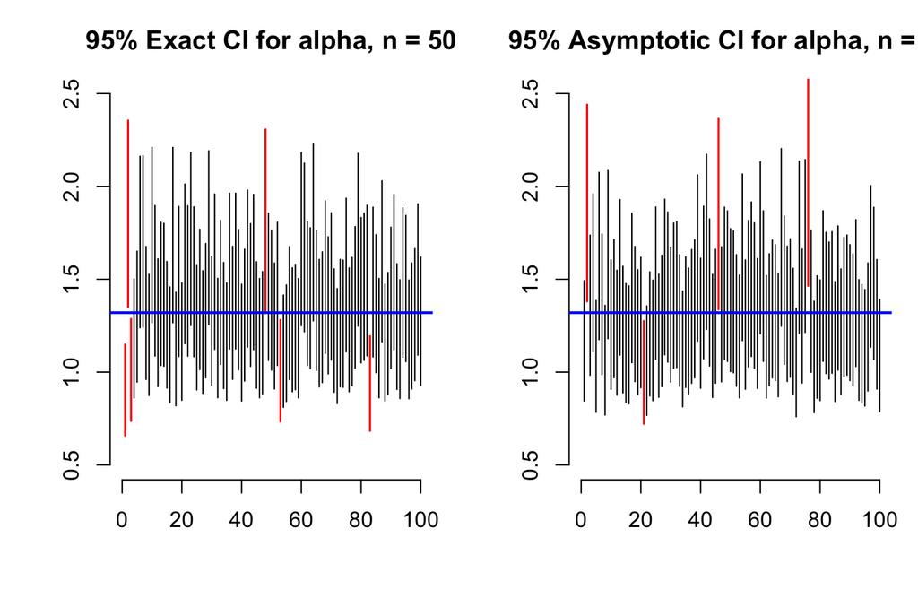

```r
set.seed(SEED)
sample.size <- 50
no.of.intervals <- 100

par(mfrow = c(1, 2), mar = c(4.2, 4.2, 3, 1))

# Left: Exact Pivot CI
plot.new()
plot.window(xlim = c(0, no.of.intervals), ylim = c(0.5, 2.5))
axis(1); axis(2)
title(paste0("95% Exact CI for alpha, n = ", sample.size))
for (i in 1:no.of.intervals) {
  x_sim <- rpareto(sample.size, alpha = alpha.true, xm = XM)
  T_sim <- sum(log(x_sim / XM))
  lo <- qchisq(a / 2, df = 2 * sample.size) / (2 * T_sim)
  up <- qchisq(1 - a / 2, df = 2 * sample.size) / (2 * T_sim)
  if (lo > alpha.true || up < alpha.true) {
    segments(c(i), c(lo), c(i), c(up), col = "red", lwd = 1.5)
  } else {
    segments(c(i), c(lo), c(i), c(up), col = "black")
  }
}
abline(h = alpha.true, lwd = 2, col = "blue")

# Right: Asymptotic Normal (Wald) CI
plot.new()
plot.window(xlim = c(0, no.of.intervals), ylim = c(0.5, 2.5))
axis(1); axis(2)
title(paste0("95% Asymptotic CI for alpha, n = ", sample.size))
for (i in 1:no.of.intervals) {
  x_sim <- rpareto(sample.size, alpha = alpha.true, xm = XM)
  alpha_hat <- sample.size / sum(log(x_sim / XM))
  ME <- z * alpha_hat / sqrt(sample.size)
  lo <- alpha_hat - ME
  up <- alpha_hat + ME
  if (lo > alpha.true || up < alpha.true) {
    segments(c(i), c(lo), c(i), c(up), col = "red", lwd = 1.5)
  } else {
    segments(c(i), c(lo), c(i), c(up), col = "black")
  }
}
abline(h = alpha.true, lwd = 2, col = "blue")
```

```r
par(mfrow = c(1, 1))
```

**Discussion (read together with the table above).**

- The **Exact** interval has coverage equal to the nominal level $0.95$ for every $n$ (up to Monte Carlo error) and balances its tail errors evenly (`MissLow` $\approx 2.5\%$, `MissHigh` $\approx 2.5\%$), because $2\alpha T \sim \chi^2_{2n}$ is an exact pivot.
- The **Asymptotic Normal (Wald)** interval is symmetric around $\hat{\alpha}$, while the sampling distribution of $\hat{\alpha} = n/T$ is right-skewed and biased upwards by $\alpha/(n-1)$. For small $n$ ($n=10$), this produces noticeable asymmetry between `MissLow` and `MissHigh`.
- **Convergence for large $n$:** Both methods converge to virtually the same coverage and interval length once $n \ge 100$, and are indistinguishable at our real sample size $n =$ 751.
- **100-Interval Segment Plot ($n = 50$):** Across 100 simulated samples, roughly 95% of the intervals (black segments) bracket the true $\alpha_0$ (blue horizontal line), while roughly 5% (red segments) miss it, visually illustrating the frequentist meaning of confidence.